# Annual report of bird monitoring activities on Gough Island

Kim Stevens, Vonica Perold, Roelf Daling, Steffen Oppel

26 August 2022

# 1 General overview of bird monitoring on Gough Island

## 1.1 Background for 2022

Gough Island is a World Heritage site in the South Atlantic Ocean and home to 22 seabird and 2 landbird species. Many of the species nesting on Gough are globally threatened due to the presence of invasive mice. Bird monitoring on Gough started in the 1950s, but regular monitoring with repeatable methods was initiated in 2005, and focusses on 12 bird species that are accessible and relatively easy to monitor. This report summarises the population counts and breeding success of monitored species between December 2020 and July 2022 and puts those numbers into longer-term perspective for each species. Because there is no time on Gough when no species breeds, this report was generated while some species (Grey Petrel, Atlantic Petrel, Tristan Albatross) were in the middle of their respective breeding season. Results for these species therefore refer to the previous year.

In June and July 2021 the RSPB attempted to eradicate invasive mice from Gough, which required a large amount of work including the construction of infrastructure, the temporary captive holding of safeguarding populations for the two landbird species, and the aerial broadcast of toxic bait across the island to kill mice. Although the operation was completed and bait was applied to all of the island at least twice, some mice survived on Gough and were first detected in December 2021. This report does *not* provide any background and detail about the eradication operation and any associated activities, but solely reports on the routine monitoring activities and their outcomes. Any effects of the eradication operation on routine monitoring activities and results are briefly mentioned for the affected species.

## 1.2 General overview of breeding success across species

In the season starting in 2021 we monitored the breeding success of 777 nests of 8 species (Table 1). For the winter-breeding species (Grey Petrel, Atlantic Petrel, Tristan Albatross), the summary refers only to the first year (2021), as the nest monitoring for 2022 was still ongoing at the time this report was produced. Breeding success is generally calculated as the number of large chicks or fledglings divided by the number of nests, occupied burrows, or incubating adults. In addition, breeding success for albatrosses is also measured in other study areas by simply counting adult birds and chicks, and these study areas often have lower breeding success than the focal study colonies. Table 1.2.1 therefore presents breeding success from both approaches, and is arranged by increasing breeding success to allow easy comparison of the species with the lowest and the highest breeding success.

Note that for the winter-breeding species (Tristan Albatross and Grey Petrel), the breeding success that is reported is from 2021, and thus from *before* the eradication operation, while the breeding success of all other species occurred *after* the eradication operation. The much reduced mouse abundance after July 2021 therefore resulted in higher breeding success than in previous years for some species, with the exception of Southern Giant Petrels and Great Shearwaters.

Table 1.2.1: Summary of breeding success on Gough Island in 2021-2022, based on either intensively monitored nests in a focal study area or area counts of adults and chicks (for albatrosses only)

| Species | N of nests | Breeding success [%] in focal area | Breeding success [%] across several areas |
| --- | --- | --- | --- |
| Grey Petrel | 30 | 26.7 |  |
| Southern Giant Petrel | 185 | 37.8 |  |
| Atlantic Petrel | 51 | 62.7 |  |
| Tristan Albatross | 225 | 67.6 | 39.7 |
| Great Shearwater | 135 | 71.9 |  |
| Sooty Albatross | 22 | 72.7 | 74.1 |
| Atlantic Yellow-nosed Albatross | 79 | 77.2 | 76.7 |
| MacGillivray’s Prion | 50 | 82.0 |  |

## 1.3 General overview of individual bird ringing and resighting across species

The large number of individual Gough Buntings that were ringed in 2021 was due to the temporary captive holding of individuals during the eradication operation. These birds were released from October-December 2021, and many have been seen regularly across the island since their release.

Table 1.3.1: Summary of individidually marked birds that were resighted or marked on Gough Island in 2021-2022

| Species | N of adults resighted/recaptured | N of adults ringed | N of young ringed |
| --- | --- | --- | --- |
| Tristan Albatross | 1002 | 4 | 268 |
| Southern Giant Petrel | 393 | 0 | 70 |
| Atlantic Yellow-nosed Albatross | 224 | 0 | 302 |
| Gough Bunting | 40 | 41 | 70 |
| MacGillivray’s Prion | 35 | 0 | 0 |
| Tristan Skua | 9 | 0 | 0 |
| Sooty Albatross | 3 | 0 | 0 |

## 1.4 Summary of the number of unusual and noteworthy mortalities

From December 2020 to July 2022 we recorded 98 noteworthy carcasses of birds on Gough Island. This recording was initiated when an unusually large number of Atlantic Yellow-nosed Albatross carcasses were discovered within regular census areas since 2017. Seabird carcasses of larger species are only collected opportunistically where non-natural or unusual mortality is suspected. No effort is made to count or collect carcasses of smaller seabird species like prions that are routinely predated by skuas. Note that this report does *not* attempt to present a comprehensive list of mortality of birds that occurred as a consequence of the mouse eradication programme, but the mortality of skuas and moorhens was largely due to primary and secondary poisoning.

Table 1.4.1: Summary of recorded bird carcasses found on Gough Island in 2021-2022

| Species | N of unringed carcasses recorded | N of ringed carcasses recorded |
| --- | --- | --- |
| Tristan Skua | 34 | 4 |
| Atlantic Yellow-nosed Albatross | 20 | 2 |
| Gough Moorhen | 16 |  |
| Soft-plumaged Petrel | 3 |  |
| Cattle Egret | 2 |  |
| Gough Bunting | 2 | 5 |
| Atlantic Petrel | 1 |  |
| Broad-billed Prion | 1 |  |
| Grey-backed Storm-petrel | 1 |  |
| Southern Giant Petrel | 1 | 3 |
| Tristan Albatross | 1 | 2 |

# 2 Species-specific accounts of population status and breeding success

The following sections provide detailed data and summaries about abundance status and breeding success in 2022 for each species. The accounts are arranged in alphabetic order to facilitate the rapid look-up of information by non-experts.

## 2.1 Atlantic Petrel (*Pterodroma incerta*)

Three 120 m transects are located in the lowlands around the base, each consisting of 14-15 quadrats (8 m by 8 m) on alternate sides of the transect centreline. All quadrats are surveyed during laying (July) to count occupied burrows; focal quadrats are surveyed during hatching (September) and fledging (December) to count small and large chicks and determine breeding success.

Table 2.1.1: Burrow occupancy and abundance of burrows in each Atlantic Petrel transect in 2021.

| Transect | N of active burrows | N of empty burrows | Total N of burrows checked | Occupancy rate (%) |
| --- | --- | --- | --- | --- |
| Blechnum Bridge | 128 | 77 | 205 | 62.4 |
| Helipad | 15 | 17 | 32 | 46.9 |
| Prion Cave | 101 | 69 | 170 | 59.4 |
| Total | 244 | 163 | 407 | 60.0 |

Burrow occupancy is used as an indicator of population size, because the total number of breeding pairs is impossible to assess for burrow-nesting species. Fig. 2.1.1 shows the trend in Atlantic Petrel burrow occupancy over the past 10 years.

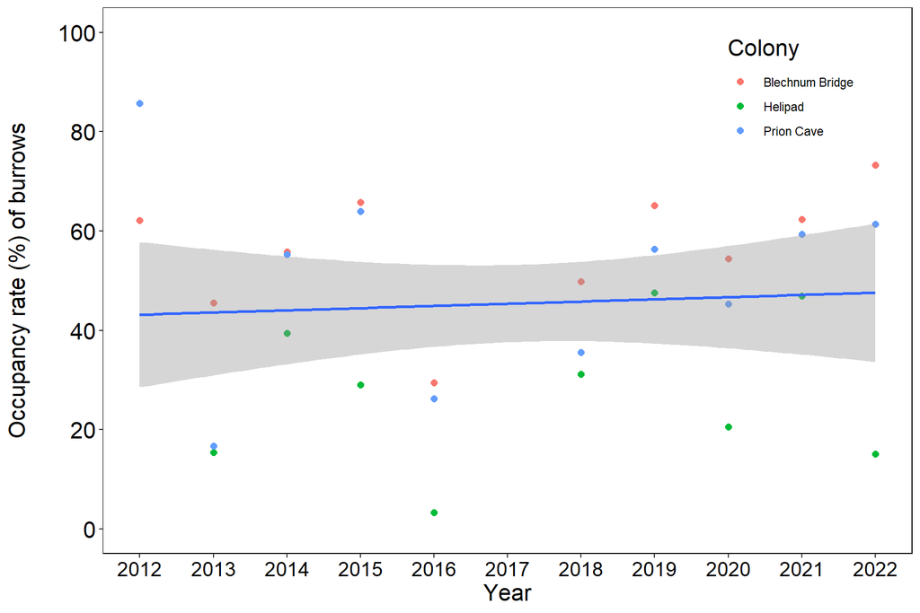

Fig. 2.1.1. Burrow occupancy of Atlantic Petrels on Gough Island over the past 10 years in three monitoring colonies

Because burrows are counted in quadrats of fixed size, we can also calculate the density of breeding birds as an alternative measure of population size and trend over time. While occupancy compares the relative proportion of occupied vs. unoccupied burrows, density uses the raw count of burrows occupied by a breeding bird divided by the size of the quadrats and may differ from occupancy rate if abandoned burrows are no longer recognisable after several years. Fig. 2.1.2 shows the trend in Atlantic Petrel density over the past 10 years.

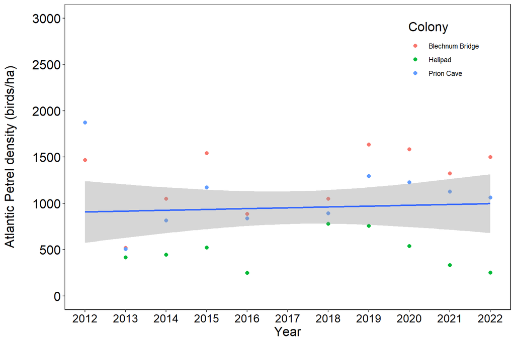

Fig. 2.1.2. Density of breeding Atlantic Petrels on Gough Island over the past 10 years in three monitoring colonies

Table 2.1.2: Breeding success of Atlantic Petrels in 2021.

| Transect | N of active burrows | N of small chicks | N of fledglings | Hatching success (%) | Fledging success (%) | Breeding success (%) |
| --- | --- | --- | --- | --- | --- | --- |
| Blechnum Bridge | 28 | 25 | 21 | 89.3 | 84.0 | 75.0 |
| Helipad | 4 | 3 | 3 | 75.0 | 100.0 | 75.0 |
| Prion Cave | 19 | 12 | 8 | 63.2 | 66.7 | 42.1 |
| Total | 51 | 40 | 32 | 78.4 | 80.0 | 62.7 |

Breeding success until 2018 was summarised based on individually labelled burrows, but since 2019 we use the count of occupied burrows and chicks in 9 focal monitoring quadrats. Fig. 2.1.3 shows the trend in Atlantic Petrel breeding success over the past 10 years. No breeding success data could be retrieved for 2011-2013.

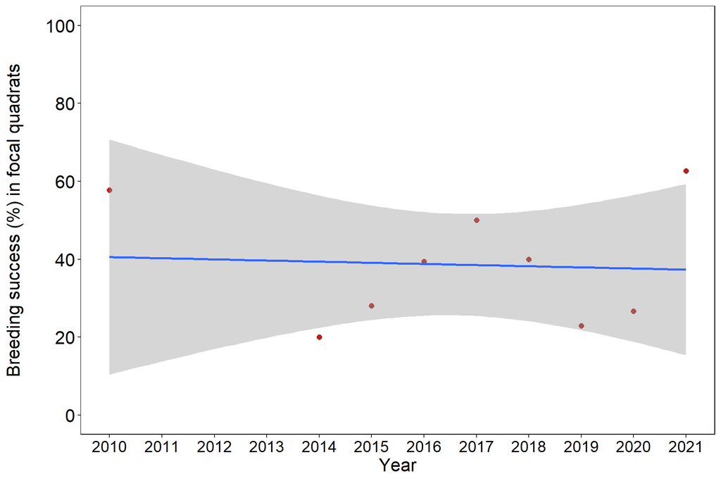

Fig. 2.1.3. Breeding success of Atlantic Petrels on Gough Island over the past 10 years

## 2.2 Atlantic Yellow-nosed Albatross (*Thalassarche chlororhynchos*)

There are 11 study areas located in the lowlands around the base, where all breeding pairs are counted to provide long-term data on abundance trends. The number of incubating birds counted in October is used as an indicator of population size, with an incubating bird representing a breeding pair at the time of the census. Fig. 2.2.1 shows the trend in Atlantic Yellow-nosed Albatross abundance over the past 10 years. Note that prior to 2015 census areas were delineated by landmarks only (since 2015 boundaries were marked by GPS), which may lead to minor imprecision in counts due to the inclusion or exclusion of birds in border areas.

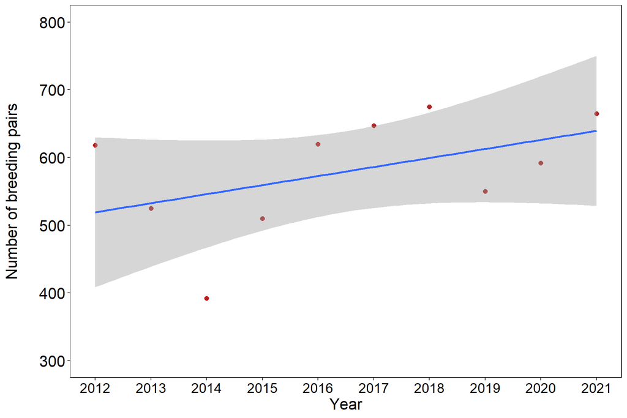

Fig. 2.2.1. Number of breeding pairs of Atlantic Yellow-nosed Albatross in 11 survey areas on Gough Island over the past 10 years

Breeding success is measured in count areas 2, 3, 8, and 10 by visiting during incubation (October), hatching (December) and fledging (March). Hatching success is the number of small chicks counted in December, divided by the number of breeding pairs; fledging success is the number of large chicks counted in March, divided by the number of small chicks. Breeding population size and breeding success for 2021 are presented in Table 2.2.1 below. Please note that due to the eradication work and a mouse discovery in December no count of chicks was possible in December 2021, and therefore no hatching and fledging success could be calculated.

Table 2.2.1: Abundance and breeding success of Atlantic Yellow-nosed Albatrosses in 2021.

[output not shown]

Breeding success is also assessed in an intensive study colony (Area 1), where individual nests are marked and monitored to completion. This approach allows the most reliable data for long-term comparisons of breeding success. Fig. 2.2.2 shows the trend in Atlantic Yellow-nosed Albatross breeding success over the past 10 years.

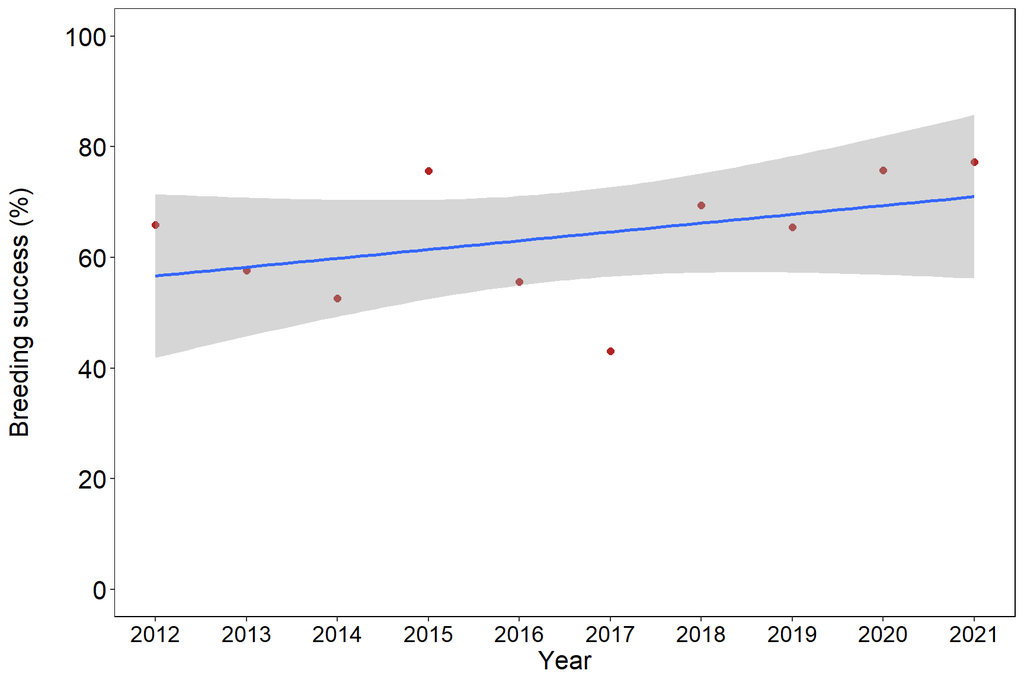

Fig. 2.2.2. Breeding success of Atlantic Yellow-nosed Albatross in Area 1 on Gough Island over the past 10 years

## 2.3 Great Shearwater (*Ardenna gravis*)

Three transects are located in the lowlands around the base, each consisting of 10-11 quadrats (8 m by 8 m) on alternate sides of the transect centreline. All quadrats are surveyed during laying (November) to count occupied burrows; focal quadrats are surveyed during hatching (January) and fledging (April) to count small and large chicks and determine breeding success.

Table 2.3.1: Burrow occupancy and abundance of burrows in each Great Shearwater transect in 2021.

| Transect | N of active burrows | N of empty burrows | Total N of burrows checked | Occupancy rate (%) |
| --- | --- | --- | --- | --- |
| Seal Beach | 179 | 76 | 255 | 70.2 |
| Snoekgat | 162 | 42 | 204 | 79.4 |
| Tumbledown | 247 | 118 | 365 | 67.7 |
| Total | 588 | 236 | 824 | 71.4 |

Burrow occupancy is used as an indicator of population size, because the total number of breeding pairs is impossible to assess for burrow-nesting species. Fig. 2.3.1 shows the trend in Great Shearwater burrow occupancy since 2014, when counts were systematically recorded (data from before 2014 refer to labelled burrows and are not comparable).

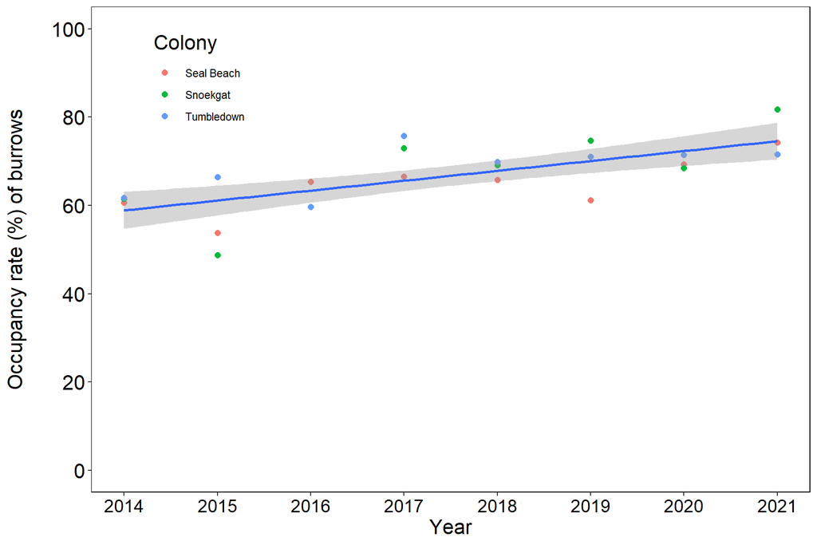

Fig. 2.3.1. Burrow occupancy of Great Shearwaters on Gough Island since 2014

Because burrows are counted in quadrats of fixed size, we can also calculate the density of breeding birds as an alternative measure of population size and trend over time. While occupancy compares the relative proportion of occupied vs. unoccupied burrows, density uses the raw count of burrows occupied by a breeding bird divided by the size of the quadrats and may differ from occupancy rate if abandoned burrows are no longer recognisable after several years. Fig. 2.3.2 shows the trend in Great Shearwater density since 2014.

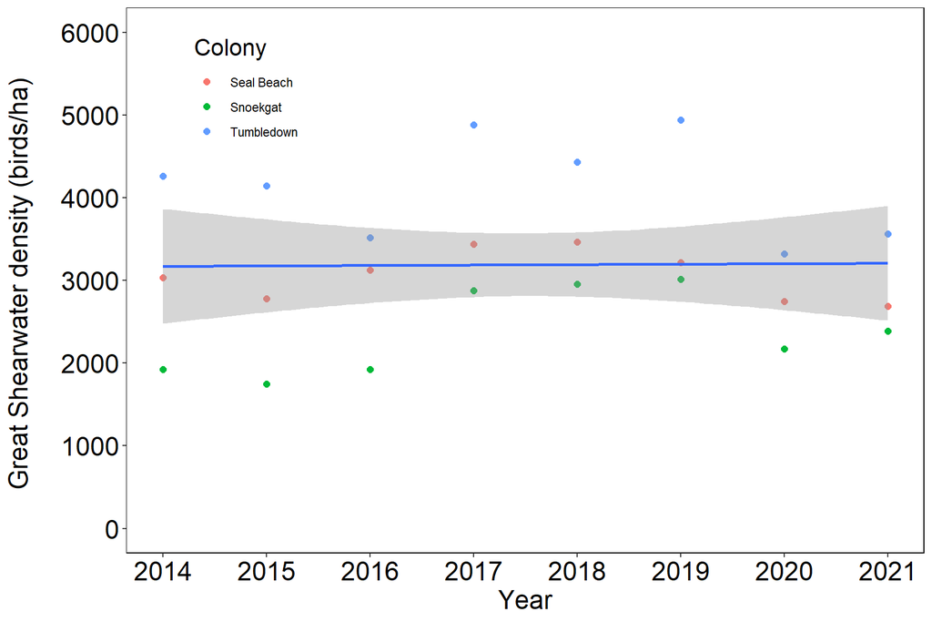

Fig. 2.3.2. Density of Great Shearwaters on Gough Island since 2014 in three monitoring colonies

Breeding success is assessed in three focal quadrats per transect, and is calculated as the number of large chicks counted in April divided by the number of occupied burrows counted in November. Hatching success is the number of small chicks counted in January divided by the number of occupied burrows, and fledging success is the number of large chicks counted in April divided by the number of small chicks. Hatching success and breeding success for 2021 are presented in Table 2.3.2 below.

Table 2.3.2: Breeding success of Great Shearwaters in 2021.

| Transect | N of active burrows | N of small chicks | N of fledglings | Hatching success (%) | Fledging success (%) | Breeding success (%) |
| --- | --- | --- | --- | --- | --- | --- |
| Seal Beach | 57 | 48 | 39 | 84.2 | 81.2 | 68.4 |
| Snoekgat | 43 | 35 | 31 | 81.4 | 88.6 | 72.1 |
| Tumbledown | 35 | 33 | 27 | 94.3 | 81.8 | 77.1 |
| Total | 135 | 116 | 97 | 85.9 | 83.6 | 71.9 |

Breeding success until 2018 was summarised based on individually labelled burrows, but since 2019 we use the count of occupied burrows and chicks in 9 focal monitoring quadrats. Fig. 2.3.3 shows the trend in Great Shearwater breeding success over the past 10 years.

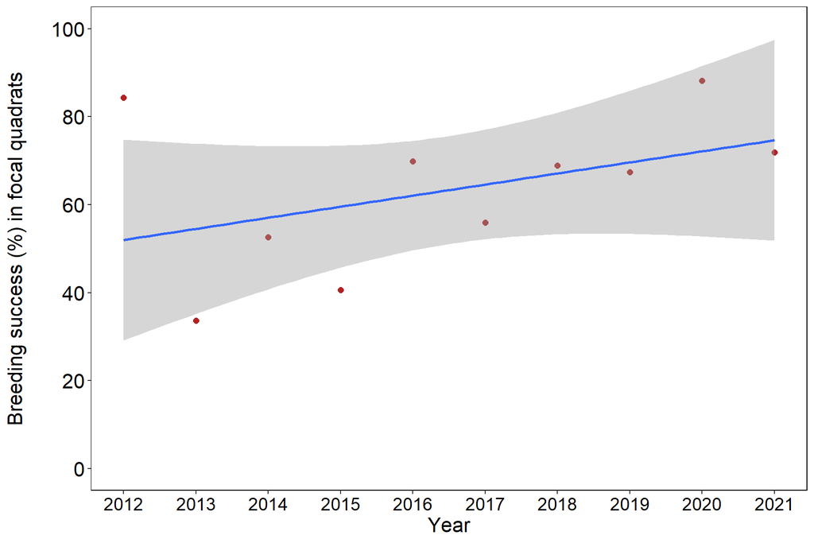

Fig. 2.3.3. Breeding success of Great Shearwaters on Gough Island over the past 10 years

## 2.4 Grey Petrel (*Procellaria cinerea*)

Grey Petrels nest in burrows in the uplands of Gough, and monitoring their abundance is not feasible. Therefore, monitoring is limited to their breeding success. Previously marked Grey Petrel breeding burrows in Gonydale are checked regularly during laying period (March-May), and all occupied burrows are followed until fledging (September). Note that the breeding success reported here refers to the 2021 breeding season which started *before* the mouse eradication operation.

Table 2.4.1: Abundance and breeding success of Grey Petrels in 2021.

| N of nests | N of small chicks | N of fledglings | Hatching success (%) | Fledging success (%) | Breeding success (%) |
| --- | --- | --- | --- | --- | --- |
| 30 | 17 | 8 | 56.7 | 47.1 | 26.7 |

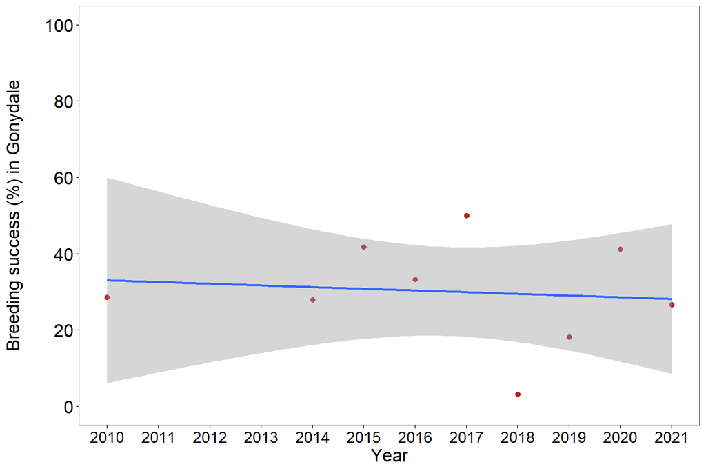

Fig. 2.4.1. Breeding success of Grey Petrels on Gough Island over the past 11 years

## 2.5 MacGillivray’s Prion (*Pachyptila macgillivrayi*)

On Gough Island, MacGillivray’s Prion was considered as the same species as Broad-billed Prion *P. vittata* until around 2014, when the occurrence of consistently different bill sizes led to the realisation that there were actually two prion species nesting on Gough. The species nests in small burrows and an accessible cave (‘Prion Cave’) on Gough, where 50 nests are monitored every year from laying (November) to fledging (March). Breeding success is calculated as the number of large chicks counted in March divided by the number of marked nests counted in November. Hatching success is the number of small chicks counted in January divided by the number of marked nests, and fledging success is the number of large chicks counted in March divided by the number of small chicks. Hatching success and breeding success for 2021 are presented in Table 2.5.1 below.

Table 2.5.1: Breeding success of MacGillivray’s Prion in 2021.

| N of nests | N of small chicks | N of fledglings | Hatching success (%) | Fledging success (%) | Breeding success (%) |
| --- | --- | --- | --- | --- | --- |
| 50 | 45 | 41 | 90 | 91.1 | 82 |

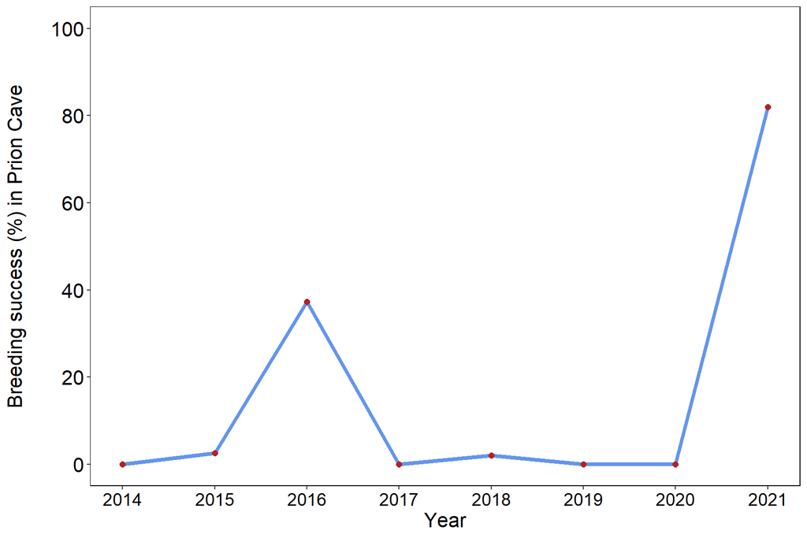

Fig. 2.5.1. Breeding success of MacGillivray’s Prion on Gough Island since 2014

## 2.6 Northern Rockhopper Penguin (*Eudyptes moseleyi*)

There are two long-term study areas at Tumbledown and Seal Beach, and since 2017 the colony at Rockhopper Point has been surveyed using photos. At Tumbledown and Seal Beach all breeding pairs are counted during laying (in October) to provide long-term data on abundance trends. Fig. 2.6.1 shows the trend in Northern Rockhopper Penguin abundance over the past 10 years at Tumbledown and Seal Beach.

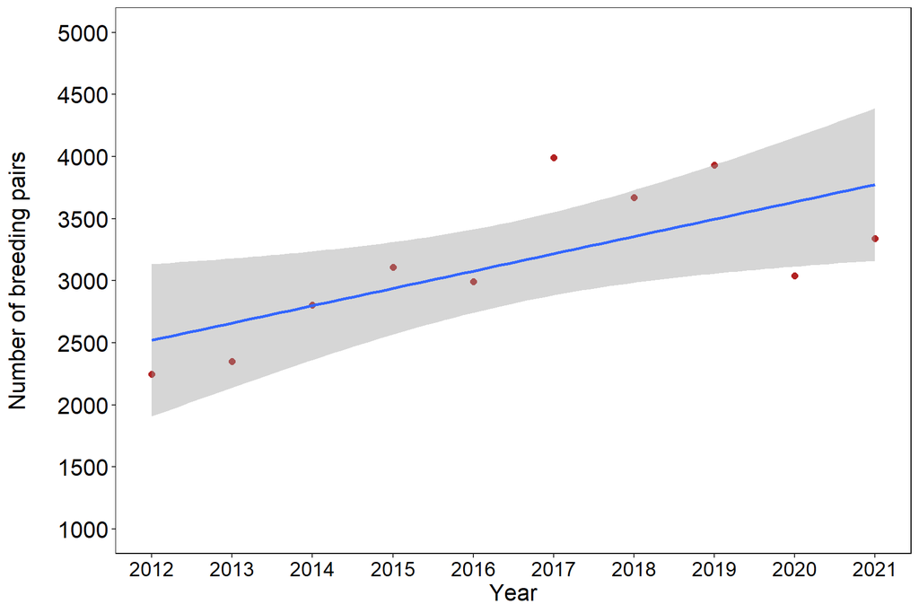

Fig. 2.6.1. Number of breeding pairs of Northern Rockhopper Penguins at Tumbledown and Seal Beach on Gough Island over the past 10 years

Breeding success is measured at Tumbledown and Seal Beach by counting incubating birds (October), freshly hatched chicks (November) and larger chicks during the creche period (January). Breeding success is the number of large chicks counted in January divided by the number of breeding pairs. Breeding population size and breeding success for 2021 are presented in Table 2.6.1 below. Note that due to nests and small chicks hidden between boulders and rock crevices the count of small chicks is not very accurate, and the number of small chicks being counted may be lower than the number of chicks that actually hatched. No estimates for hatching and fledging success are therefore provided as they may be misleading.

Table 2.6.1: Abundance and breeding success of Northern Rockhopper Penguins in 2021.

| Colony | N of pairs | N of small chicks | N of creche chicks | Breeding success (%) |
| --- | --- | --- | --- | --- |
| Seal Beach | 1251 | 889 | 501 | 40.0 |
| Tumbledown | 2090 | 1339 | 825 | 39.5 |
| Total | 3341 | 2228 | 1326 | 39.7 |

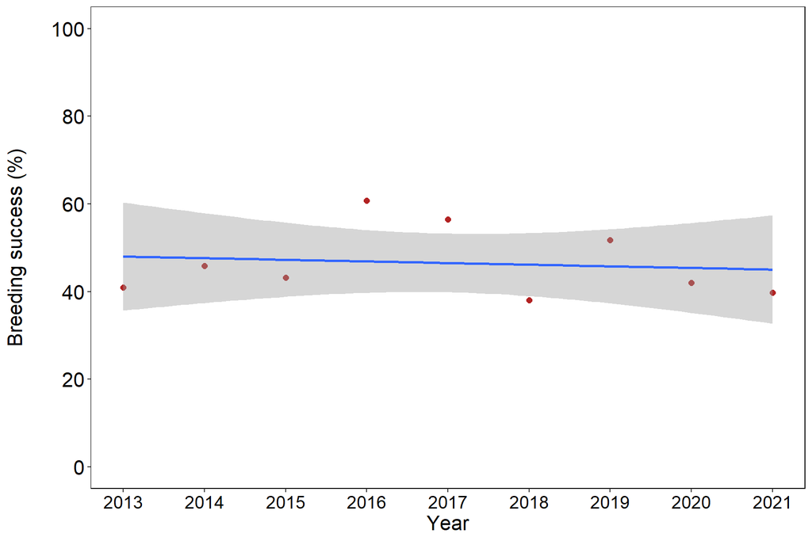

Fig. 2.6.2. Breeding success of Northern Rockhopper Penguin on Gough Island over the past 9 years

## 2.7 Sooty Albatross (*Phoebetria fusca*)

There are 16 study areas located along the sea cliffs around the weather station and inland cliffs towards Tafelkop, where all breeding pairs are counted to provide long-term data on abundance trends. The number of incubating birds counted in October is used as an indicator of population size, with an incubating bird representing a breeding pair at the time of the census. Fig. 2.7.1 shows the trend in Sooty Albatross abundance over the past 10 years.

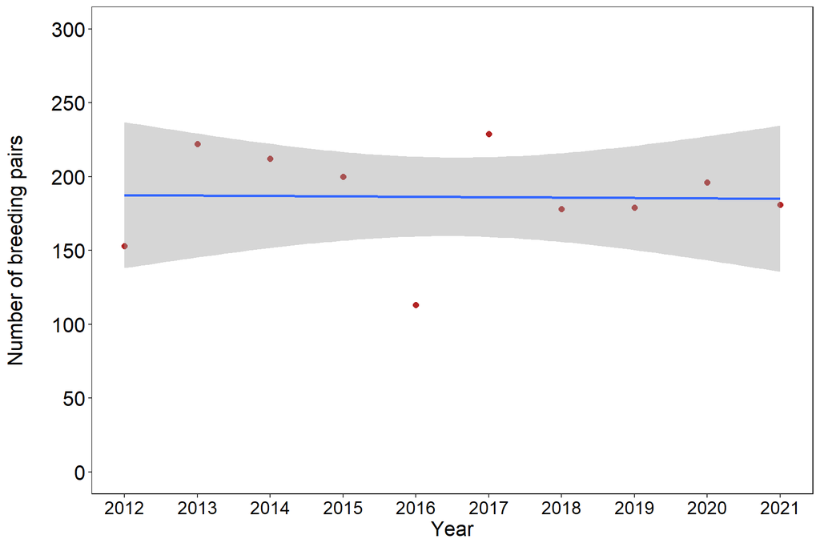

Fig. 2.7.1. Number of breeding Sooty Albatross pairs in 16 survey areas on Gough Island over the past 10 years

Breeding success is coarsely assessed in these 16 count areas by visiting during incubation (October), hatching (December) and fledging (April). Hatching success is the number of small chicks counted in December divided by the number of breeding pairs; fledging success is the number of large chicks counted in April divided by the number of small chicks. Note that fledging success may be overestimated because the small chicks are difficult to see. Breeding population size and breeding success for 2021 are presented in Table 2.7.1 below.

Table 2.7.1: Abundance and breeding success of Sooty Albatrosses in 2021.

| Count area | N of pairs | N of small chicks | N of fledglings | Hatching success (%) | Fledging success (%) | Breeding success (%) |
| --- | --- | --- | --- | --- | --- | --- |
| SOAL Plot 1 | 6 | 4 | 4 | 66.7 | 100.0 | 66.7 |
| SOAL Plot 2 | 9 | 7 | 7 | 77.8 | 100.0 | 77.8 |
| SOAL Plot 3 | 7 | 7 | 4 | 100.0 | 57.1 | 57.1 |
| SOAL Plot 4 | 11 | 8 | 8 | 72.7 | 100.0 | 72.7 |
| SOAL Plot 5 | 14 | 12 | 10 | 85.7 | 83.3 | 71.4 |
| SOAL Plot 6 | 7 | 6 | 6 | 85.7 | 100.0 | 85.7 |
| SOAL Plot 7 | 27 | 20 | 20 | 74.1 | 100.0 | 74.1 |
| SOAL Plot 8 | 30 | 27 | 27 | 90.0 | 100.0 | 90.0 |
| SOAL Plot 9 | 33 | 22 | 22 | 66.7 | 100.0 | 66.7 |
| SOAL Plot 10 | 2 | 2 | 1 | 100.0 | 50.0 | 50.0 |
| SOAL Plot 11 | 5 | 4 | 3 | 80.0 | 75.0 | 60.0 |
| SOAL Plot 12 | 1 | 0 | 0 | 0.0 |  | 0.0 |
| SOAL Plot 13 | 7 | 5 | 5 | 71.4 | 100.0 | 71.4 |
| SOAL Plot 14 | 3 | 3 | 3 | 100.0 | 100.0 | 100.0 |
| SOAL Plot 15 | 0 |  |  |  |  |  |
| Total | 162 | 127 | 120 | 78.4 | 94.5 | 74.1 |

Breeding success is also assessed in detail for ~20-60 individual nests along the cliffs from Crane Point to Seal Beach, where individual nests are monitored to completion. This approach offers the most reliable data for long-term comparisons of breeding success. Fig. 2.7.2 shows the trend in Sooty Albatross breeding success over the past 10 years. Only 3 nests were monitored in 2013, hence no representative estimate of breeding success is available.

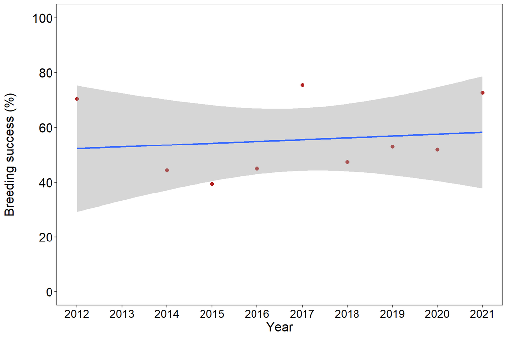

Fig. 2.7.2. Breeding success of Sooty Albatrosses on Gough Island over the past 10 years

## 2.8 Southern Giant Petrel (*Macronectes giganteus*)

Southern Giant Petrel breeding pairs are counted around the entire island in September during the Tristan Albatross chick count. The number of incubating pairs counted in September is used as an indicator of population size to provide long-term data on abundance trends. Fig. 2.8.1 shows the trend in Southern Giant Petrel abundance over the past 10 years.

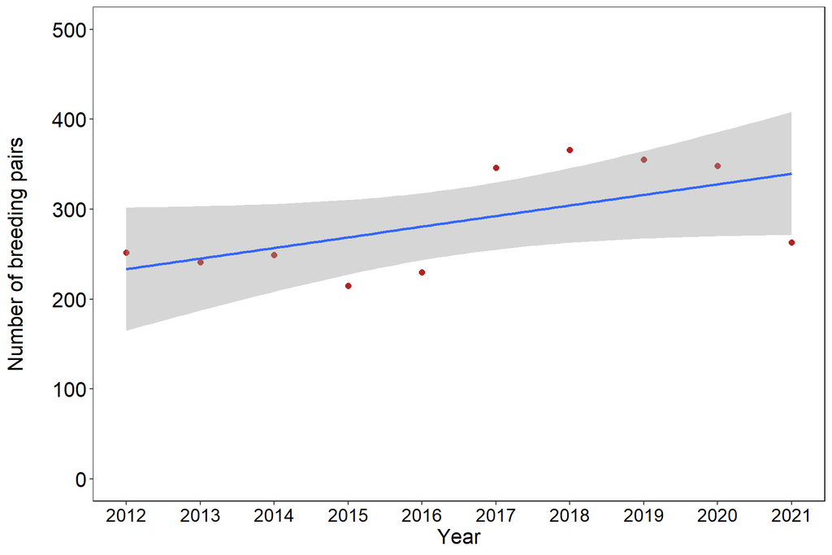

Fig. 2.8.1. Number of breeding pairs of Southern Giant Petrels on Gough Island over the past 10 years

Breeding success is intensively monitored at the Low Hump colony by marking all nests during incubation (September), and following these nests by regular visits until fledging (January). Since 2020, only nests in the main parts of the Low Hump colony are monitored. Hatching success is the proportion of nests that hatched a chick, fledging success is the proportion of hatched chicks that fledged, and breeding success is the proportion of nests that fledged a chick. Breeding population size and breeding success for 2021 are presented in Table 2.8.1 below.

Table 2.8.1: Abundance and breeding success of Southern Giant Petrels in 2021.

| Count area | N of pairs | Hatching success (%) | Fledging success (%) | Breeding success (%) |
| --- | --- | --- | --- | --- |
| GP Valley | 48 |  |  |  |
| Low Hump | 194 | 69.2 | 54.7 | 37.8 |
| West Point | 21 |  |  |  |

The nest monitoring data from Low Hump also allow long-term comparisons of breeding success. Fig. 2.8.2 shows the trend in Southern Giant Petrel breeding success over the past 10 years.

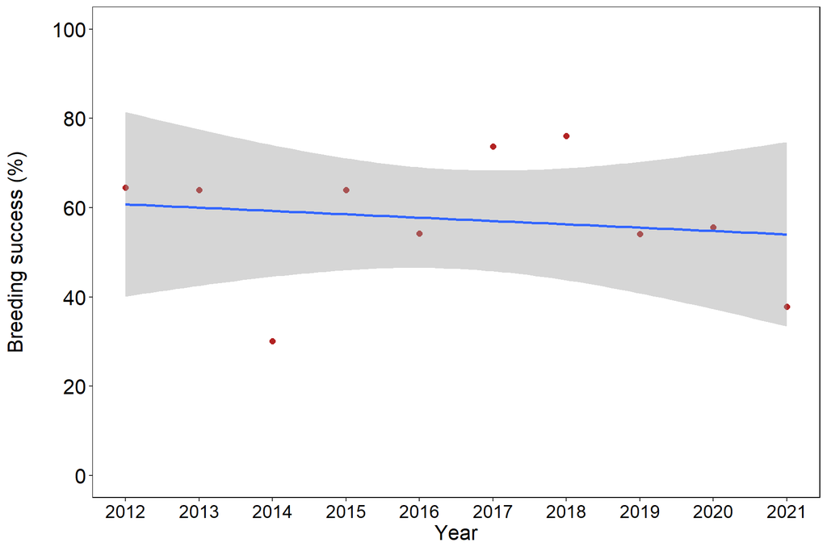

Fig. 8.2. Breeding success of Southern Giant Petrels on Gough Island over the past 10 years

## 2.9 Tristan Albatross (*Diomedea dabbenena*)

Tristan Albatross breeding pairs are counted around the entire island in late January and early February during incubation. The number of incubating pairs can vary from year to year depending on the breeding success of the previous year, because adult birds that raised a chick in the previous year will not return to Gough in the current year. The count of incubators is used as an indicator of population size to provide long-term data on abundance trends. Fig. 2.9.1 shows the trend in Tristan Albatross abundance over the past 15 years.

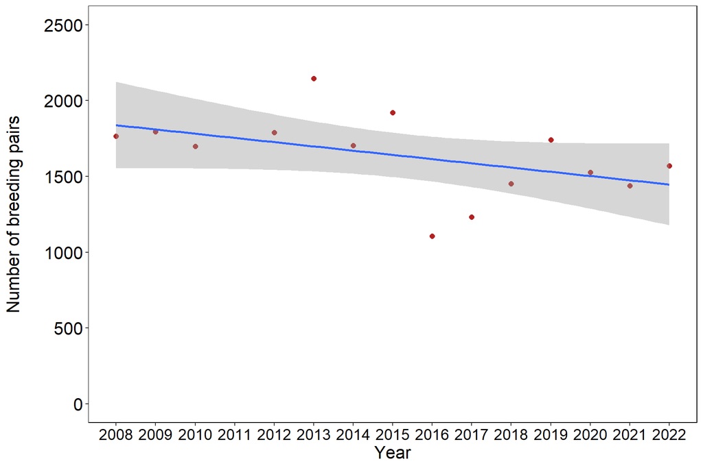

Fig. 2.9.1. Number of breeding pairs of Tristan Albatross on Gough Island over the past 15 years

Table 2.9.1: Abundance and breeding success of Tristan Albatross in 2021. Count areas are sorted by breeding success.

| Count area | N of pairs | N of large chicks (Sept) | Breeding success (%) |
| --- | --- | --- | --- |
| False Peak | 84 | 10 | 11.9 |
| Green Hill North | 61 | 13 | 21.3 |
| Triple Peak | 99 | 23 | 23.2 |
| West Point | 187 | 53 | 28.3 |
| Albatross Plain | 291 | 96 | 33.0 |
| GP Valley | 167 | 57 | 34.1 |
| Green Hill South | 73 | 29 | 39.7 |
| Spire Crag | 169 | 73 | 43.2 |
| Tarn Moss | 52 | 35 | 67.3 |
| Hummocks | 46 | 31 | 67.4 |
| Gonydale | 196 | 139 | 70.9 |
| Tafelkop | 14 | 13 | 92.9 |
| Total | 1439 | 572 | 39.7 |

Breeding success is also intensively monitored in Gonydale, Tafelkop and the Hummocks by marking all nests during incubation (January), and following these nests by regular visits until fledging (November/December). Although these data come from an area of the island where breeding success is generally higher, they allow a more consistent measurement of breeding success that is less influenced by weather and the timing and completeness of chick counts than the complete island counts in January and September. Fig. 2.9.2. shows the breeding success from both monitoring series for the past 10 years.

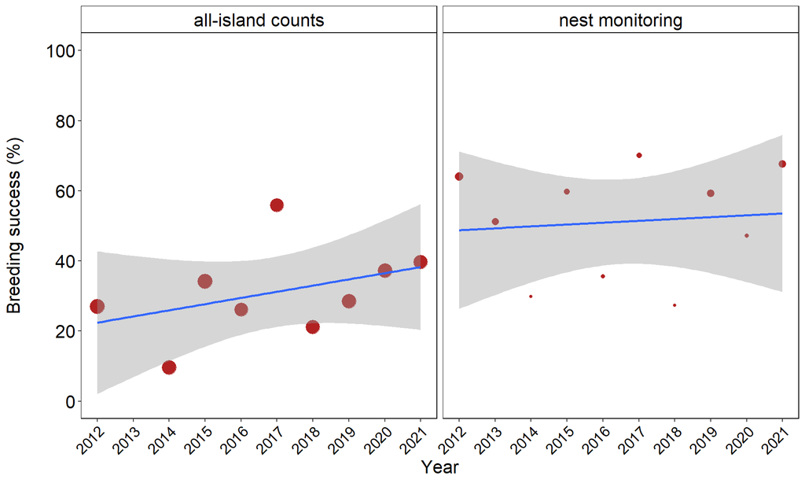

Fig. 2.9.2. Breeding success of Tristan Albatrosses on Gough Island over the past 10 years based on counts of incubating pairs and large chicks around the island (left panel), and nest monitoring at Gonydale, Tafelkop and the Hummocks (right panel). Size of points reflects sample size (=number of incubating pairs).

## 2.10 Tristan Skua (*Stercorarius antarcticus hamiltoni*)

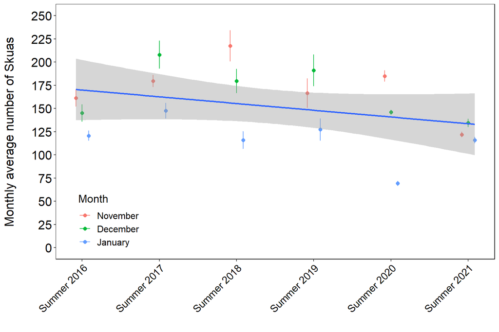

Fig. 2.10.1. Average number of non-breeding Tristan Skuas at four clubs on Gough Island since summer 2016. Points present average total number for Nov, Dec, and Jan.

# 3 Landbird monitoring

Two endemic landbirds live on Gough, the Gough Bunting *Rowettia goughensis* and the Gough Moorhen *Gallinula comeri*. Since spring 2016 these birds have been counted along 50 transects that are each 100 m long and spread out along trails all over the island. Complete surveys are conducted in September and in February, along with the Tristan Albatross round-island count. The Gough Moorhen was more common in lowland habitats (fern bush, coastal tussock), while the Gough Bunting is more common in upland habitats (moorland, sphagnum bogs).  
Landbird surveys are conducted repeatedly in each season (spring, autumn) in a way that allows us to estimate abundance while accounting for imperfect detection. However, in this report we present only a basic summary of the raw data without attempting to account for imperfect detection.  
Note that during the mouse eradication operation in 2021 additional counts were conducted in May and in August, and the population of the moorhen decreased significantly. More detail on the status of the moorhen is available in a separate report. Fig. 3.1. shows the trend since spring 2016 of the average number of Gough Moorhens and Gough Buntings counted per transect in each species’ preferred habitat.

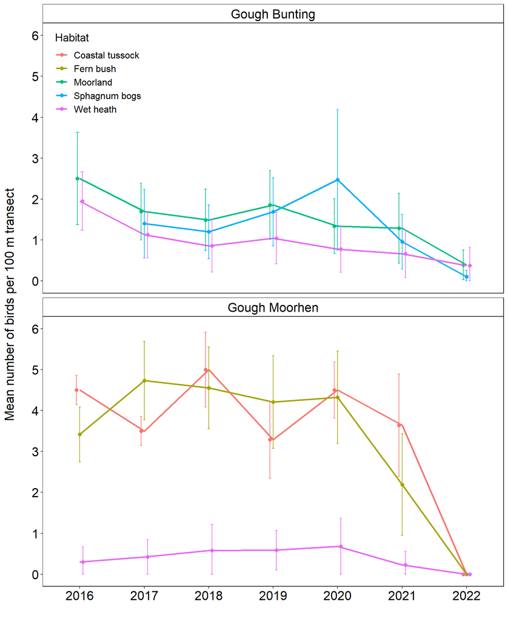

Fig. 3.1. Average number of Gough Buntings and Gough Moorhens on 100 m transect counts since spring 2016. Note that for each species only abundance in its primary habitat is shown, although individuals can also be encountered in other habitat at very low numbers.

# 4 Appendix: list of all deployed rings

Appendix 1: Details of all ring deployments on Gough Island in 2021. Note that this table includes ring replacements of previously ringed birds.

| Species | Age of bird | Ring type | Ring colour | Ring size (mm) | Ring number |
| --- | --- | --- | --- | --- | --- |
| Atlantic Yellow-nosed Albatross | Chick | metal | metal | 12.5 | MA52826 |
| Atlantic Yellow-nosed Albatross | Chick | metal | metal | 12.5 | MA52827 |
| Atlantic Yellow-nosed Albatross | Chick | metal | metal | 12.5 | MA52828 |
| Atlantic Yellow-nosed Albatross | Chick | metal | metal | 12.5 | MA52829 |
| Atlantic Yellow-nosed Albatross | Chick | metal | metal | 12.5 | MA52830 |
| Atlantic Yellow-nosed Albatross | Chick | metal | metal | 12.5 | MA52832 |
| Atlantic Yellow-nosed Albatross | Chick | metal | metal | 12.5 | MA52833 |
| Atlantic Yellow-nosed Albatross | Chick | metal | metal | 12.5 | MA52834 |
| Atlantic Yellow-nosed Albatross | Chick | metal | metal | 12.5 | MA52835 |
| Atlantic Yellow-nosed Albatross | Chick | metal | metal | 12.5 | MA52836 |
| Atlantic Yellow-nosed Albatross | Chick | metal | metal | 12.5 | MA52837 |
| Atlantic Yellow-nosed Albatross | Chick | metal | metal | 12.5 | MA52838 |
| Atlantic Yellow-nosed Albatross | Chick | metal | metal | 12.5 | MA52839 |
| Atlantic Yellow-nosed Albatross | Chick | metal | metal | 12.5 | MA52840 |
| Atlantic Yellow-nosed Albatross | Chick | metal | metal | 12.5 | MA52841 |
| Atlantic Yellow-nosed Albatross | Chick | metal | metal | 12.5 | MA52842 |
| Atlantic Yellow-nosed Albatross | Chick | metal | metal | 12.5 | MA52843 |
| Atlantic Yellow-nosed Albatross | Chick | metal | metal | 12.5 | MA52844 |
| Atlantic Yellow-nosed Albatross | Chick | metal | metal | 12.5 | MA52845 |
| Atlantic Yellow-nosed Albatross | Chick | metal | metal | 12.5 | MA52846 |
| Atlantic Yellow-nosed Albatross | Chick | metal | metal | 12.5 | MA52847 |
| Atlantic Yellow-nosed Albatross | Chick | metal | metal | 12.5 | MA52848 |
| Atlantic Yellow-nosed Albatross | Chick | metal | metal | 12.5 | MA52849 |
| Atlantic Yellow-nosed Albatross | Chick | metal | metal | 12.5 | MA52850 |
| Atlantic Yellow-nosed Albatross | Chick | metal | metal | 12.5 | MA52852 |
| Atlantic Yellow-nosed Albatross | Chick | metal | metal | 12.5 | MA52853 |
| Atlantic Yellow-nosed Albatross | Chick | metal | metal | 12.5 | MA52854 |
| Atlantic Yellow-nosed Albatross | Chick | metal | metal | 12.5 | MA52855 |
| Atlantic Yellow-nosed Albatross | Chick | metal | metal | 12.5 | MA52856 |
| Atlantic Yellow-nosed Albatross | Chick | metal | metal | 12.5 | MA52857 |

[output cut: 599 more lines]